# PCFL: Week 6 wrap-up

### Last week’s games

| Away | Away points | Home | Home points |
| --- | --- | --- | --- |
| Middle Earth Hangry Hobbits | 100.90 | Georgia Peanuts | 107.02 |
| The G.O.A.T. | 112.82 | Jumpin’ Jaheims | 91.73 |
| First Timers The FTs | 103.40 | Southern Sharks | 110.19 |
| KC Gophers | 100.18 | Captain Clairvoyant | 102.15 |
| Athens Team Sasquatch | 115.24 | Pigskin on the Gridiron | 110.94 |

This was a week of nail-biters, with all but one contest determined by 10 points or less. My Peanuts just avoided getting roasted by the Hobbit’s fire. The First Timers couldn’t quite jump the (Southern) Sharks. Captain Clairvoyant was able to dig out the Gophers, and Richard’s Pigskin team continued to slide, getting spiked by Team Sasquatch. The one easy win this week was Jacob’s group living up to their name.

Everyone but Evan scored between 100 and 115 points this week. #parity

#### Best performing players

Here’s last week’s **10 best performing players.** The bench variable shows whether they got left on the bench or not.

| Player | Points | Team | Benched |
| --- | --- | --- | --- |
| Derrick Henry | 39.40 | Captain Clairvoyant | 0 |
| Justin Jefferson | 36.10 | First Timers The FTs | 1 |
| Deshaun Watson | 32.00 | Middle Earth Hangry Hobbits | 0 |
| Matt Ryan | 31.64 | Georgia Peanuts | 1 |
| Julio Jones | 30.70 | Pigskin on the Gridiron | 0 |
| Carson Wentz | 29.42 | First Timers The FTs | 1 |
| Kyler Murray | 28.92 | The G.O.A.T. | 0 |
| Ryan Tannehill | 28.56 | Middle Earth Hangry Hobbits | 1 |
| Kenyan Drake | 28.40 | Jumpin’ Jaheims | 0 |
| Lamar Jackson | 28.24 | Athens Team Sasquatch | 1 |

Derrick Henry had a breakout week, as did the rookie Justin Jefferson for the Vikings (though on the bench). The Atlanta offense also had some top players in Matt Ruan and Julio Jones.

#### Best addition and worst starters

There were 13 players added last week. Which was the **best new addition**?

| Date added | Name | Points | Team |
| --- | --- | --- | --- |
| 2020-10-15 | Younghoe Koo | 20.00 | Georgia Peanuts |
| 2020-10-15 | Travis Fulgham | 16.50 | Georgia Peanuts |
| 2020-10-15 | Rob Gronkowski | 16.30 | Captain Clairvoyant |
| 2020-10-15 | Chase Claypool | 16.10 | Athens Team Sasquatch |
| 2020-10-15 | Ryan Fitzpatrick | 16.04 | Southern Sharks |
| 2020-10-15 | Dolphins D/ST | 12.00 | Pigskin on the Gridiron |
| 2020-10-15 | Patriots D/ST | 8.00 | Georgia Peanuts |
| 2020-10-15 | Graham Gano | 8.00 | Pigskin on the Gridiron |
| 2020-10-15 | Jason Sanders | 6.00 | Middle Earth Hangry Hobbits |
| 2020-10-18 | Damien Harris | 3.80 | Jumpin’ Jaheims |
| 2020-10-15 | Alexander Mattison | 3.50 | Athens Team Sasquatch |
| 2020-10-16 | Noah Fant | 0.00 | Athens Team Sasquatch |
| 2020-10-16 | Latavius Murray | 0.00 | Athens Team Sasquatch |

Let’s hear it for the kickers! Younghoe Koo was the top new add (and a key part of my victory). Brian, Robbie, and Sarah also had good adds. It’s the time of year when some folks are streaming defenses, and the Dolphins were a nice pickup by Richard.

Who should have been **left on the bench** this week–the lowest points scored by starters?

| Name | Points | Team |
| --- | --- | --- |
| Rams D/ST | -1.0 | Jumpin’ Jaheims |
| Hunter Henry | 0.0 | Captain Clairvoyant |
| Alvin Kamara | 0.0 | Athens Team Sasquatch |
| Noah Fant | 0.0 | Athens Team Sasquatch |
| Mike Evans | 1.5 | Jumpin’ Jaheims |

Another week, another defense with negative points. Some other names were on bye and added before I updated stats.

Who won the **best scoring bench** award last week?

| Team | Points |
| --- | --- |
| First Timers The FTs | 107.02 |
| Georgia Peanuts | 89.24 |
| KC Gophers | 63.17 |
| Athens Team Sasquatch | 62.64 |
| Southern Sharks | 49.25 |
| The G.O.A.T. | 49.12 |
| Middle Earth Hangry Hobbits | 48.16 |
| Pigskin on the Gridiron | 41.37 |
| Captain Clairvoyant | 33.05 |
| Jumpin’ Jaheims | 23.22 |

Erin and Trav could have used some of those 107 points, as their bench outscored their starters this week.

### League standings and season stats

Here’s a look at our current standings

| Team | Division | W | L | Points scored | Points allowed | Points rank | Playoff rank |
| --- | --- | --- | --- | --- | --- | --- | --- |
| Captain Clairvoyant | Grits | 5 | 1 | 746.87 | 655.62 | 2 | 1 |
| Athens Team Sasquatch | Grits | 5 | 1 | 701.85 | 688.58 | 4 | 2 |
| The G.O.A.T. | Grits | 4 | 2 | 719.31 | 684.04 | 3 | 3 |
| First Timers The FTs | Hot Dish | 3 | 3 | 775.68 | 689.16 | 1 | 4 |
| Georgia Peanuts | Hot Dish | 3 | 3 | 687.38 | 695.27 | 5 | 5 |
| Southern Sharks | Hot Dish | 3 | 3 | 677.66 | 670.69 | 7 | 6 |
| KC Gophers | Hot Dish | 3 | 3 | 630.37 | 643.35 | 8 | 7 |
| Middle Earth Hangry Hobbits | Hot Dish | 2 | 4 | 680.52 | 687.05 | 6 | 8 |
| Jumpin’ Jaheims | Grits | 1 | 5 | 627.89 | 736.63 | 9 | 9 |
| Pigskin on the Gridiron | Grits | 1 | 5 | 615.34 | 712.48 | 10 | 10 |

Here’s our current awards leaders from these standings:

- Yellow shirt (most points): First Timers
- D-FENCE (least points allowed): KC Gophers
- Tough luck (points rank - playoff rank): The First Timers
- Lucky ducks (playoff rank - points rank): Team Sasquatch

Here’s a list of the **top five scoring performances** so far this season.

| Team | Week | Points scored | Result |
| --- | --- | --- | --- |
| First Timers The FTs | 2 | 171.28 | W |
| Captain Clairvoyant | 3 | 150.32 | W |
| Middle Earth Hangry Hobbits | 5 | 142.36 | W |
| First Timers The FTs | 4 | 141.14 | W |
| The G.O.A.T. | 1 | 139.20 | W |

This is unchanged since last week.

Lastly, here’s a look at the **points trendline** for each team.

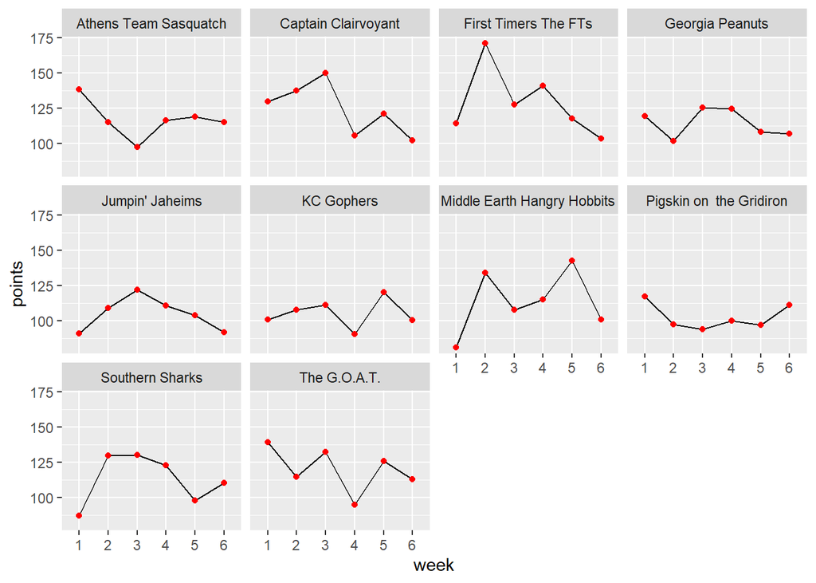

## Next week’s games

Here’s a quick summary of next week’s matchups:

| week | away_team | away_points | home_team | home_points | range |
| --- | --- | --- | --- | --- | --- |
| 7 | Georgia Peanuts | 687.38 | The G.O.A.T. | 719.31 | 31.93 |
| 7 | Jumpin’ Jaheims | 627.89 | First Timers The FTs | 775.68 | 147.79 |
| 7 | Southern Sharks | 677.66 | KC Gophers | 630.37 | 47.29 |
| 7 | Captain Clairvoyant | 746.87 | Athens Team Sasquatch | 701.85 | 45.02 |
| 7 | Pigskin on the Gridiron | 615.34 | Middle Earth Hangry Hobbits | 680.52 | 65.18 |

Another good matchup on tap between Captain Clairvoyant and Team Sasquatch. The potential mismatch of the week is the suddenly vulnerable First Timers against the Jumpin’ Jaheims. Good luck all! (And remember to check your bye weeks.)